# Homework 2

# 1 Coding a Poisson random variable

Suppose R can only generate uniform random variables. How can you take advantage of this and generate Poisson random variables?

## 1.1 Solution

Let $X$ be a Poisson random variable of mean $\lambda$. Let $p_i = \mathbb{P}(X =i)$. We split the unit interval up into intervals $J_i$ of length $p_i$; this adds up to one, since the $p_i$ are a pmf. If $U$ is uniformly distributed on $[0,1]$, and $U \in J_i$, then we report $X=i$. This is accomplished in the R code below, and we perform various checks to make sure we didn’t mess up.

```r
probpois <- function(x){
  n = x[1]
  lambda = x[2]
  p = exp(-lambda) * (lambda^n) / factorial(n)
  p
}

cumpois<- function(x){
  n = x[1]
  lambda = x[2]
  sum=0
  for(i in 0:n){
    sum <- probpois( c(i, lambda)) + sum
  }
  sum
}

poisrv<- function(lambda){
u = runif(1)
m = -1
if( u < cumpois(c(0, lambda))){m <- 0}
i=1
while(m==-1){
  if(u < cumpois(c(i,lambda))){m <-i}
  i <- i+1
}
m
}

z= replicate(10000, poisrv(2.56))
mean(z)
```

```
## [1] 2.547
```

```r
var(z)
```

```
## [1] 2.516443
```

```r
sum(z==3)/10000
```

```
## [1] 0.224
```

```r
dpois(3, 2.56)
```

```
## [1] 0.2161597
```

# 2 Inverse transform method

Use the inverse tranform method to generate an exponential random variable

## 2.1 Solution

Recall that if $X$ is exponential with rate $\lambda$, then
$$\mathbb{P}(X \geq x) = e^{-\lambda x}.$$
Thus if $F$ is the cdf, its inverse has explicit formula given by
$$F^{-1} (y) = \frac{-\log (1-y)}{\lambda}.$$

The inverse transform method tells that if $U$ is uniformly distributed on the unit interval then $F^{-1}(U)$ has the same as $X$. The R code below illustrates this fact.

```r
lambda = 2.3
inverseT <- function(y){
  inv =-log(1-y) / lambda
  inv
}
x = runif(10000)
z = inverseT(x)
1/mean(z)
```

```
## [1] 2.279966
```

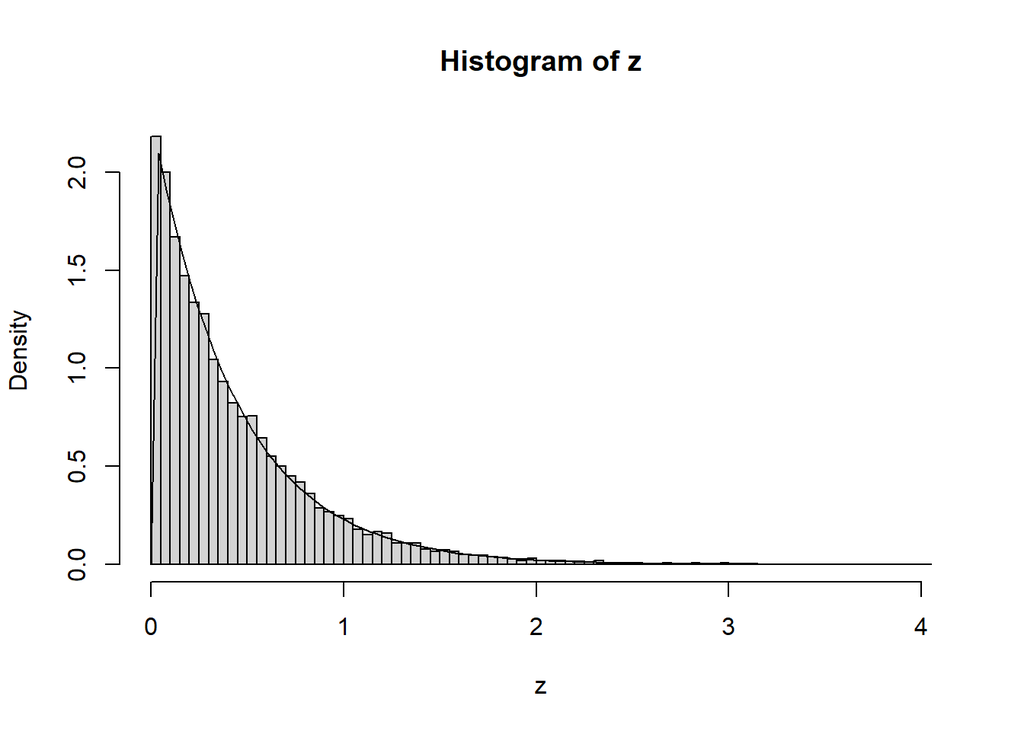

```r
hist(z, prob=TRUE, breaks=100)
curve(dexp(x,2.3), add=TRUE)
```

# 3 The value of Pi

Inscribe a circle in a square. Estimate the value of $\pi$ by computing the ratio of the number of times a uniformly chosen point on the square ends up in the circle.

## 3.1 Solution

This ratio $r$ will tend towards the ratio of the area of circle to the area of square. We modify the code from the *Random variables: theory and practice* slides.

```r
pointtrack <- function(N){
  n=0
  k=1
  while(k<N+1){
  x = 2*runif(1) -1
  y = 2*runif(1) -1
if (x^2 + y^2 <1) { n<-n+1}
  k<-k+1
  }
  n/N
}
pointtrack(100000)*4
```

```
## [1] 3.14608
```

# 4 Acceptance/Rejection

Using an exponential random variable, generate a normal random variable that is conditioned to be be positive; from here, adjust this result to get a normal random variable.

## 4.1 Solution

Recall that the density of a standard normal is given
$$x \mapsto \frac{1}{\sqrt{2\pi}} e^{-x^2/2}.$$

By symmetry, the density conditioned to be positive, is given by

$$x \mapsto \frac{2}{\sqrt{2\pi}} e^{-x^2/2}.$$

We can plot this against $e^{-x}$ the density of the exponential with rate $1$, to guess what $M$ to choose.

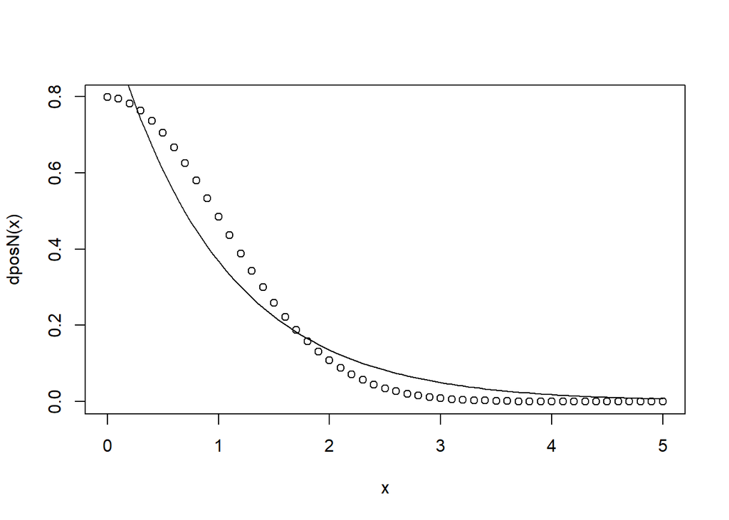

```r
dposN <- function(x){
  d = 2/ sqrt(2 * pi) * exp( -x^2/2)
  d
}
x=seq(0, 5, by=0.1)
plot(x, dposN(x))
curve(dexp(x), add=TRUE)
```

It is not hard to see we may take $M=2$.

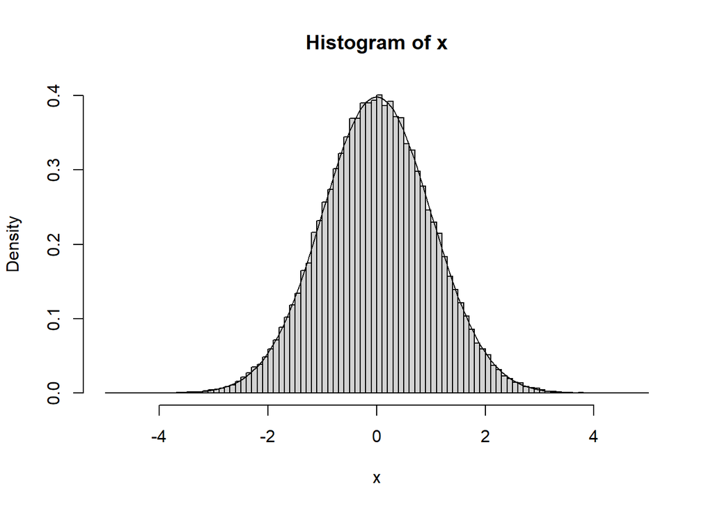

```r
ar <- function(){
x = -5
while(x==-5){
u = runif(1)
y = rexp(1)
w = dposN(y)/(2*dexp(y))
if( u < w){x <- y}
}
x
}
arfix<- function(){
  x=(2*rbinom(1,1,0.5)-1)*ar()
  x
}
x=replicate(100000, arfix())
z = seq(-5,5,0.1)
hist(x, prob=TRUE, z)
curve(dnorm, add=TRUE)
```

# 5 Total variatonal distance

Let $X$ and $Y$ be Poisson random variables with means $\lambda > \mu$. Show that
$$d_{TV}(X, Y) \leq 2 (1-\exp( \mu-\lambda))$$

## 5.1 Solution

Recall that if $Z$ is Poisson with mean $\lambda - \mu$ and independent of $Y$, then $X'=Z + Y$ is a Poisson random variable with mean $\lambda$. Thus
$$d_{TV}(X, Y) = d_{TV}(X', Y) \leq 2\mathbb{P}(X' \not =Y) = 2 \mathbb{P}(Z >0) = 2 (1-\exp( \mu-\lambda)).$$

# 6 Reversibility

Let $P$ be transition matrix on a state space $S$, and $\pi$ be a probability measure on $S$. We say that $\pi$ is **reversible** for $P$ if $\pi_i p_{ij} = \pi_j p_{ji}$.

- Check that the stationary distribution from a random walk on a finite graph is reversible.
- Let $P$ be a transition matrix on a state space $S$. Check that if $\pi$ is reversible, then it is stationary.
- Let $\pi$ be a reversible distribution for the transition matrix $P$ on a state space $S$. Let $X$ be Markov chain with transition matrix $P$, that is started at $\pi$. Let $a, b,c,d \in S$. Show that
  $$\mathbb{P}(X_0=a,X_1=b, X_2=c, X_3=d) = \mathbb{P}(X_0=d,X_1=c,X_2=b, X_3=a).$$

## 6.1 Solution

- Let $G=(V, E)$ be a simple undirected graph. Recall that $\pi_i = \deg(i)/ 2|E|$, and the transition matrix $P$ is given by
  $$p_{ij}=\frac{1}{\deg(i)}\mathbf{1}[(i,j) \in E].$$
  We have the following calculation:
  $$\begin{eqnarray*}
  \pi_i p_{ij} &=& \frac{1}{2|E|}\mathbf{1}[(i,j) \in E] \\
  &=& \frac{\deg(j)}{2|E|} \Big(\frac{1}{\deg(j)}\Big)\mathbf{1}[(j,i) \in E] \\
  &=& \pi_j p_{ji}.
  \end{eqnarray*}$$
- We have
  $$\begin{eqnarray*}
  (\pi P)_j &=& \sum_{i \in S} \pi_i p_{ij} \\
  &=& \sum_{i \in S} \pi_j p_{ji} = \pi_j \sum_{i \in S} p_{ji} \\
  &=& \pi_j.
  \end{eqnarray*}$$
- We have by reversibility that

$$\begin{eqnarray*}
\mathbb{P}(X_0=a,X_1=b, X_2=c, X_3=d) &=& [\pi(a)p_{ab}] p_{bc} p_{cd} \\
&=& p_{ba} [ \pi(b)p_{bc} ] p_{cd} \\
&=& p_{ba} p_{cb} [\pi(c) p_{cd} ] \\
&=& p_{ba} p_{cb} p_{dc} \pi(d) \\
&=& \pi(d) p_{dc} p_{cb} p_{ba} \\
&=& \mathbb{P}(X_0=d,X_1=c,X_2=b, X_3=a),
\end{eqnarray*}$$
as desired.

# 7 Simple card shuffling

Suppose that I have $n=52$ cards, arranged in some initial order. Consider the following procedure: I choose two cards with probability $1/ {n \choose 2}$, and then change their position; repeat.

- Describe this procedure as a Markov chain. Can you code it?
- With this procedure, can you get from an initial ordering to *any* other ordering? Why?
- Do you think it has a stationary distribution? If, so, what is it?

## 7.1 Solution

- Recall that $S_n$ is the group of all permutations of $[n]=\{1, 2, \ldots, n\}$; that is, $g \in S_n$ if and only if $g$ is bijection from $[n]$ to itself. Group multiplication, is given by function composition, so that we write $gh = g\circ h$. Recall that a **transposition** $g \in S_n$, is a permutation such that there exists two elements $i,j \in [n]$ such that $g(i) = j$, and for all other elements $x \in [n]$ are fixed; that is, $g(x) =x$. Let $X$ be a Markov chain on $S_n$ with transition probabilities given by
  $$\mathbb{P}(X_1= \sigma g\ | \ X_0 = g) = 1 / {n \choose 2}$$
  for every transposition $\sigma \in S_n$.
- Yes. Recall that every permutation is a product of transpositions. For example, consider the case $n=5$, and $g(1)=2, g(2)=5$, $g(3)=1$, $g(5)=3$, and $g(4)=4$. This is usually graphically displayed via $g=(1253).$ Note that
  $$g= (12)(25)(53).$$
- The uniform distribution $\pi$ on $S_n$ assigns probability $1/n!$ to each of the $n!$ elements of $S_n$ is clearly stationary.

```r
deck = seq(1,52, 1)
deck
```

```
##  [1]  1  2  3  4  5  6  7  8  9 10 11 12 13 14 15 16 17 18 19 20 21 22 23 24 25
## [26] 26 27 28 29 30 31 32 33 34 35 36 37 38 39 40 41 42 43 44 45 46 47 48 49 50
## [51] 51 52
```

```r
shuffle <- function(x){
  t=sample(52, 2, replace=FALSE)
  a=t[1]
  b=t[2]
  da = x[a]
  db = x[b]
  x[a] <- db
  x[b] <- da
  x
}
y=shuffle(deck)
y
```

```
##  [1]  1  2  3  4  5  6  7  8  9 10 11 12 13 14 28 16 17 18 19 20 21 22 23 24 25
## [26] 26 27 15 29 30 31 32 33 34 35 36 37 38 39 40 41 42 43 44 45 46 47 48 49 50
## [51] 51 52
```

```r
shuffle(y)
```

```
##  [1]  1  2  3  4  5  6  7  8  9 10 11 12 13 14 28 16 17 18 19 20 21 22 43 24 25
## [26] 26 27 15 29 30 31 32 33 34 35 36 37 38 39 40 41 42 23 44 45 46 47 48 49 50
## [51] 51 52
```

```r
for( i in 1:100){
  y <- shuffle(y)
}
y
```

```
##  [1] 31 27  8  4 25  5 39 35 17 52 29 26  1 41 13 33 14 45 11 30  6 10 44 43 46
## [26] 24 50 42 36 34 38 32 47  2 23 51 16 15 48  3 18 49 12 20 37 21 40 19 28 22
## [51]  9  7
```

# 8 Version: 20 October 2021

- [Rmd Source](https://tsoo-math.github.io/ucl/QHW2-sol.Rmd)